# 第7回 総合演習：データを選び、しきい値を誤りの重さで決める

## 前回からの接続

第6回は、携帯電話のメッセージから迷惑メッセージを見分け、混同行列（confusion matrix）で評価しました。ロジスティック回帰（logistic regression）で確率を出すと、しきい値を動かすたびに、見逃しと誤検出が入れ替わりました。

今日は総合演習です。データを選ぶところから、1本の解析を通します。期末レポートでやることを、ひと通り先にやってみます。そして、第6回で残った「どこで切ればよいか」に、2つの誤りの重さから答えます。

## 今日の分析目標

ネットショップの訪問から、購入を見分けられるか。見分けたとして、どこで切ればよいかに答える。

まず、公開データの置き場（UCI機械学習リポジトリ）で候補を比べ、データを選びます。次に、12本の列からロジスティック回帰で購入の確率を出し、混同行列とAUCで測ります。その成績を信じてよいかを、列を1本ずつ外して確かめます。最後に、見逃しと誤検出に重さを置き、損の合計がいちばん小さいしきい値を選びます。

もう1つのねらいは、解析の手順を関数にまとめ、入力を替えて何度も呼べるようになることです。「列を選ぶ → 交差検証（cross-validation）で確率 → AUC」を1つの関数にし、列の組を替えて呼びます。お手本ごとに、コードを1行ずつ読み（「1行ずつ読む」）、変数の中身を見ます（「中身を見る」）。

### 公開データの世界

世の中には、誰でも使える公開データが山ほどあります。第6回のSMSも、UCI機械学習リポジトリという置き場のデータでした。今日は、その置き場から、データを選ぶところを見せます。期末レポートでは、データを選ぶところから自分で行います。

### 場面

ネットショップには、毎日たくさんの人が訪れます。ページを見て回り、買う人もいれば、何も買わずに帰る人もいます。

購入しそうな訪問に、チャットの担当者が声をかけたい。ただし、担当者の数は限られるので、誰にでも声をかけるわけにはいきません。どの訪問に声をかけるかを、購入の確率で決めたいのです。

誤りは2種類あります。買う気のある訪問に声をかけそびれる誤り（見逃し）と、買わない訪問に担当者の時間を使う誤り（誤検出）です。2つの誤りの重さは、同じではありません。

### 手元のデータ

Online Shoppers Purchasing Intentionは、あるネットショップの1年間の訪問を集めたデータです。1行が1回の訪問（セッション）で、12,330件あります。見たページの種類ごとの数と時間、直帰率・離脱率、ページ価値などの列と、購入したかどうかの列（Revenue）があります。

データはUCI機械学習リポジトリで公開されていて（CC BY 4.0）、出典（Sakar, Polat, Katircioglu, Kastro, 2019）を書けば使えます。

### 最後に出す答え

訪問の様子から、購入をどのくらい見分けられるか。そして、確率をどこで切って、声をかける訪問を決めるかです。

### 今日の一周（結果だけ先に）

コードの説明はあとにして、今日の解析を、結果だけで一度通して見ておきます。

1. データを選ぶ：UCIで3本の候補を比べ、実際の記録のネットショップを選びます。購入は0.155で、何も購入と言わなくても正解率は0.845です。
2. 作って測る：12本の列から、ロジスティック回帰で購入の確率を出します。AUCは0.877です。0.5で切ると、買った訪問の6割を見逃します。
3. 確かめる：えっ、列を1本ずつ外すと、ページ価値を外したときだけ、AUCが0.718まで下がります。データの説明を読むと、ページ価値は購入の売上から計算された値でした。使ってよいかは、いつの購入から計算したかで決まります。
4. しきい値を決める：見逃しを誤検出の5倍と置くと、0.15で切るのが、損の合計がいちばん小さくなります。
5. 時期で確かめる：2〜10月で決めたしきい値は、年末（11・12月）には、損がいちばん小さい所からずれます。

このあと、この5つの段の中身を、1つずつ開けていきます。

### 今日の問いとやること

| 段 | 問い | やること |
| --- | --- | --- |
| 選ぶ・予想（1・2節） | どのデータで、何を予想する？ | UCIで候補を比べて選び、読み込み、予想を書く |
| 作って測る（3節） | 購入を見分けられる？ | 12本の列で確率を出し、混同行列とAUCで測る |
| 確かめる（4節） | その成績、信じてよい？ | 手順を関数にし、列を1本ずつ外す。データの説明を読む |
| しきい値を決める（5節） | どこで切る？ | 2つの誤りに重さを置き、損の合計がいちばん小さいところで切る |
| 時期で確かめる（6節） | 年末にも使える？ | 2〜10月で式としきい値を決め、11・12月に当てる |

### 今日の進め方

段ごとに、まずスライドで、その段の結論までを通して聞きます。段の終わりにノートへ移り、その段の節のセルを上から実行して、スライドと同じ数が出るかを確かめます。そして、段ごとに1つあるTODOに答えます。

TODOは、実行の前に結果を予想して書き、1か所を替えて実行し、予想と比べる形です。予想が外れても、かまいません。

## 学習ゴール

この回を終えると、次のことができるようになります。

- 公開データのページを読み、1行・答えの列・件数・出どころ（実際の記録か、作ったデータか）を確かめて、データを選べる
- 標準化（standardization）とロジスティック回帰をつなぎ、交差検証で確率を出して、混同行列とAUCで測れる
- 解析の手順を関数にまとめ、列の組を替えて呼び、どの列が効いているかを確かめられる
- 成績を決めている列が何から作られたかを、データの説明で確かめられる
- 見逃しと誤検出に重さを置き、損の合計がいちばん小さいしきい値を選べる
- 時期で分けて確かめ、手元で決めたしきい値が新しい時期にずれることを説明できる

## 0. 準備

### 最初に実行する：道具を呼び出す

- 役割：このノートで使う道具（ライブラリ）を呼び出し、UCIのデータを取ってくる道具`ucimlrepo`を入れる
- 入力：なし
- 出力：なし（終わるとセルの左に ✓ が付く）

```python
!pip install -q ucimlrepo
import numpy as np
import pandas as pd
import matplotlib.pyplot as plt
```

### 図の日本語を表示できるようにする

- 役割：図の中の日本語が □ にならないようにし、図の大きさと字の大きさをそろえる
- 入力：なし
- 出力：「セットアップ完了」の表示

`try:`から先は、日本語表示の道具が動かなくなったときの保険で、中身は読まなくてかまいません。

```python
# 日本語が図の中で □ になるのを防ぐ
!pip install -q japanize-matplotlib
try:
    import japanize_matplotlib
# japanize が動かなくなったときの保険：同梱フォントを直接登録する
except Exception:
    from importlib.util import find_spec
    from matplotlib import font_manager as fm
    from pathlib import Path
    spec = find_spec('japanize_matplotlib')
    ttf = None
    if spec:
        ttf = next(Path(spec.origin).parent.rglob('*.ttf'), None)
    if ttf:
        fm.fontManager.addfont(str(ttf))
        name = fm.FontProperties(fname=str(ttf)).get_name()
        plt.rcParams['font.family'] = name

plt.rcParams['figure.figsize'] = (9, 5)
plt.rcParams['font.size'] = 13
plt.rcParams['axes.unicode_minus'] = False  # マイナス記号の化けを防ぐ
print('セットアップ完了')
```

```
セットアップ完了
```

## 1. どのデータを使う？

ここから、段1「選ぶ・予想」（1・2節）です。問いは、どのデータで、何を予想するか、です。

まず、公開データの置き場から、データを選びます。

### UCI機械学習リポジトリ

UCI機械学習リポジトリ（https://archive.ics.uci.edu/）は、1987年から、研究に使われたデータを集めて公開している置き場です。1つのデータに1つのページがあり、データの番号が付いています。第6回のSMSも、ここのデータでした。表だけでなく、文章や画像のデータもあります。

期末レポートでは、データを選ぶところから自分で行います。ここで、データの探し方と、Colabで取ってくるための番号（ID）の見つけ方を、まとめておきます。

### データの探し方

サイト（https://archive.ics.uci.edu/datasets）で、次の2つの方法で探せます。

- キーワードで探す：上の「Search datasets」か、左の検索欄に、英語の言葉を入れる（例：`shopper`、`wine`、`bike`）
- 絞り込みで探す：左の「Filters」を開き、条件で候補を絞る
  - Task：使いたい手法。Classification（分類）・Regression（回帰）・Clustering（クラスタリング）
  - Subject Area（分野）、# Instances（件数）、# Features（列の数）
  - Python：Colabから、そのまま取り込めるデータだけにする

気になったデータの名前を押すと、データのページが開きます。分野（Subject Area）・手法（Associated Tasks）・件数（# Instances）が並び、右にライセンスがあります。名前だけで決めず、ページの説明まで読みます。

### URLの中に、データの番号

データのページのURLは、次のような形です。

`https://archive.ics.uci.edu/dataset/468/online+shoppers+purchasing+intention+dataset`

`/dataset/`の次の数（ここでは468）が、データの番号（ID）です。この番号を、Colabで`fetch_ucirepo(id=468)`に渡すと、そのデータを取ってこられます。

ページ右上の「IMPORT IN PYTHON」のボタンを押すと、Colabに貼るコードがそのまま出ます。前半は次のとおりで、2行目の`id=468`が、同じ番号です。

```python
from ucimlrepo import fetch_ucirepo
online_shoppers_purchasing_intention_dataset = fetch_ucirepo(id=468)
X = online_shoppers_purchasing_intention_dataset.data.features
y = online_shoppers_purchasing_intention_dataset.data.targets
```

### お手本：Colabの中で探す

- 役割：名前に言葉を含むデータの、名前と番号（ID）を表示する
- 入力：探す言葉（英語）
- 出力：データの名前と番号の一覧

```python
from ucimlrepo import list_available_datasets
list_available_datasets(search='shopper')
```

```
----------------------------------------------------------------
The following datasets are available for search query "shopper":
----------------------------------------------------------------
Dataset Name                                    ID
------------                                    --
Online Shoppers Purchasing Intention Dataset    468
```

#### 1行ずつ読む

- 1行目：UCIのデータの一覧を出す道具`list_available_datasets`を呼び出す
- 2行目：名前に`shopper`を含み、Colabから取り込めるデータの、名前と番号（ID）を表示する

`search='shopper'`を`search='wine'`のように替えれば、別の言葉で探せます。

### お手本：分野で探す

`area`に分野（Subject Area）を渡すと、その分野のデータの名前と番号が並びます。ほかに`'Health and Medicine'`・`'Social Science'`などがあります。

```python
list_available_datasets(area='Business')
```

```
-------------------------------------
The following datasets are available:
For subject area: Business
-------------------------------------
Dataset Name                                    ID
------------                                    --
Credit Approval                                 27
Japanese Credit Screening                       28
Statlog (Australian Credit Approval)            143
Blood Transfusion Service Center                176
Wine Quality                                    186
Bank Marketing                                  222
ISTANBUL STOCK EXCHANGE                         247
Wholesale customers                             292
Dow Jones Index                                 312
Online News Popularity                          332
Default of Credit Card Clients                  350
Online Retail                                   352
Polish Companies Bankruptcy                     365
Facebook Metrics                                368
Stock Portfolio Performance                     390
Sales Transactions Weekly                       396
Daily Demand Forecasting Orders                 409
Absenteeism at work                             445
Online Shoppers Purchasing Intention Dataset    468
Real Estate Valuation                           477
Facebook Live Sellers in Thailand               488
Apartment for Rent Classified                   555
Seoul Bike Sharing Demand                       560
Iranian Churn                                   563
Taiwanese Bankruptcy Prediction                 572
Productivity Prediction of Garment Employees    597
In-Vehicle Coupon Recommendation                603
```

> 重要：サイトでキーワードか絞り込みでデータを探し、そのページのURLの`/dataset/`の次の数を読む。Colabの中なら、`list_available_datasets`で名前と番号が出る。

### ページで見ること

| 見ること | 中身 |
| --- | --- |
| 中身 | 1行は何か（1人・1回・1つ）。答えの列はどれか、2択か量か。件数と答えの割合 |
| 出どころ | ライセンスと引用する文献。実際の記録か、作ったデータ（合成データ）か。列ごとの説明 |
| 扱い | 欠測はあるか。人を判定するデータ（審査・診断など）は、扱いに配慮が要る |

授業や期末レポートでは、身近で、人を判定しないデータが扱いやすいです。

### 候補を3本、表で比べる

| 候補 | 1行 | 件数 | 答えの割合 | 出どころ |
| --- | --- | --- | --- | --- |
| ネットショップ（番号468） | 訪問1回 | 12,330 | 購入15.5% | 実際の訪問 |
| 工作機械（番号601） | 加工1回 | 10,000 | 故障3.4% | 作ったデータ |
| きのこ（番号848） | きのこ1本 | 61,069 | 毒55.5% | 作ったデータ |

どれも、2択を当てる分類（classification）のデータで、ライセンスはCC BY 4.0です。

工作機械のページには「synthetic dataset」（合成データ）とあります。本物の工場の記録は手に入りにくいので、それらしく作った、と書いてあります。作ったデータからの発見は、作った人の決めごとの発見かもしれません。きのこのページには「61069 hypothetical mushrooms」（架空のきのこ）とあり、図鑑のきのこの種をもとに作ったデータです。列20本のうち、数の列は3本だけです。

ページの件数と答えの割合は、取ってきて確かめられます（工作機械は故障の列、きのこは毒（p）の列）。

```
601 10000 件 {0: 0.966, 1: 0.034}
848 61069 件 {'p': 0.555, 'e': 0.445}
```

そこで、ネットショップに決めます。実際のネットショップの1年間の訪問の記録で、1行が身近です。購入は15.5%で、少なすぎず、偏りもあります。数の列が10本あり、今日の道具でそのまま扱えます。

### お手本：UCIから読み込む

- 役割：データの番号468で、ネットショップの表をUCIから取ってくる
- 入力：データの番号`468`
- 出力：表`raw`（12,330行、18列）

```python
from ucimlrepo import fetch_ucirepo
uci = fetch_ucirepo(id=468)
raw = pd.concat([uci.data.features, uci.data.targets], axis=1)
print(raw.shape)
```

```
(12330, 18)
```

#### 1行ずつ読む

- 1行目：UCIのデータを取ってくる道具`fetch_ucirepo`を呼び出す
- 2行目：データの番号468を渡して取ってきて、`uci`にしまう
- 3行目：特徴の表と答えの表を、横につなぐ（`pd.concat`、`axis=1`は横）
- 4行目：表の形（行の数、列の数）を表示する

#### fetch_ucirepoがしていること

データのページに置いてある表を、ネットから取ってきます。特徴の列（`uci.data.features`）と、答えの列（`uci.data.targets`）に分けて渡します。ページの説明（`uci.metadata`）も、一緒に届きます。

#### 中身を見る：答えの表

```python
uci.data.targets.head(3)
```

|  | Revenue |
| --- | --- |
| 0 | False |
| 1 | False |
| 2 | False |

答えの列はRevenue（売上）の1本。購入したらTrue、しなければFalse

### UCIにつながらないとき

UCIのページが混んでいたり、止まっていたりすると、上の読み込みのセルがエラーで止まります。そのときは、下のセルを実行します。同じ表を、この授業のデータの置き場（`DATA_DIR`）から読みます。UCIから取ってきた表を、そのまま保存したものです。

UCIから読めたときは、実行しなくてかまいません（実行しても、同じ表になります）。この節のほかのUCIのセル（候補の件数、答えの表、TODO①）は、つながらないあいだは飛ばします。

```python
# データはこのリポジトリから読み込む
DATA_DIR = ('https://raw.githubusercontent.com/k0heiun0/'
            'applied_exercise_preview/main/shared/data')
raw = pd.read_csv(f'{DATA_DIR}/online_shoppers.csv')
print(raw.shape)
```

```
(12330, 18)
```

#### 1行ずつ読む

- `DATA_DIR`の行：データの置き場所を`DATA_DIR`にしまう（Colabでは、置き場所のURLが2行に分かれて入っている）
- `pd.read_csv`の行：置き場所のファイル`online_shoppers.csv`を読み、`raw`にしまう
- `print`の行：表の形を表示する。上のセルと同じ(12330, 18)になる

### お手本：列の名前を日本語に

- 役割：英語の列の名前を、日本語の名前に替える
- 入力：表`raw`と、名前の組の辞書`names`
- 出力：表`df`

元の名前を鍵に、日本語の名前を値にした辞書です（第5回）。

```python
names = {'Administrative': '管理ページ数',
         'Administrative_Duration': '管理ページ時間',
         'Informational': '情報ページ数',
         'Informational_Duration': '情報ページ時間',
         'ProductRelated': '商品ページ数',
         'ProductRelated_Duration': '商品ページ時間',
         'BounceRates': '直帰率',
         'ExitRates': '離脱率',
         'PageValues': 'ページ価値',
         'SpecialDay': '特別な日'}
df = raw.rename(columns=names)
```

#### 1行ずつ読む

- 1〜10行目：元の列の名前と、日本語の名前の組を10個、辞書`names`にしまう
- 11行目：`rename(columns=names)`で、辞書のとおりに列の名前を替え、`df`にしまう

#### 中身を見る：辞書で引く

```python
print(names['PageValues'])
print(len(names))
```

```
ページ価値
10
```

鍵（元の名前）を渡すと、値（日本語の名前）が返る。組は10個

### お手本：0と1の列と、使う列

- 役割：週末・新規・購入を0と1の列にし、手がかりに使う12本の列の名前をリストにする
- 入力：表`df`
- 出力：列「週末」「新規」「購入」と、リスト`cols`

```python
df['週末'] = df['Weekend'].astype(int)
df['新規'] = (df['VisitorType'] == 'New_Visitor').astype(int)
df['購入'] = df['Revenue'].astype(int)
cols = ['管理ページ数', '管理ページ時間', '情報ページ数',
        '情報ページ時間', '商品ページ数', '商品ページ時間',
        '直帰率', '離脱率', 'ページ価値', '特別な日', '週末', '新規']
print(len(cols), '本の列')
```

```
12 本の列
```

#### 1行ずつ読む

- 1行目：週末ならTrue。`astype(int)`で1と0に直し、列「週末」にしまう
- 2行目：初めての訪問（New_Visitor）なら1、そうでなければ0の列「新規」
- 3行目：購入したら1、しなければ0の列「購入」。これが答えの列
- 4〜6行目：手がかりに使う12本の列の名前を、リスト`cols`にしまう
- 7行目：リストの長さ（列の本数）を表示する

#### 中身を見る：0と1の列

```python
df[['Weekend', '週末', 'VisitorType', '新規']].head(3)
```

|  | Weekend | 週末 | VisitorType | 新規 |
| --- | --- | --- | --- | --- |
| 0 | False | 0 | Returning_Visitor | 0 |
| 1 | False | 0 | Returning_Visitor | 0 |
| 2 | False | 0 | Returning_Visitor | 0 |

3件とも平日で、再訪（Returning_Visitor）。だから両方0

OS・ブラウザ・地域・流入元の列は、1、2、3…の番号で書いてあります。番号の大小には意味がない（地域3は地域1の3倍、ではない）ので、今日は使いません。月も今日は使いません。数の列10本と、0と1の列2本で進みます。

## 2. どんな訪問が買う？

読み込めました。次は、列が何を表すかと、答えの割合を見ます。そして、結果を見る前に、予想を書きます。

### 列の説明

| 列 | 中身 |
| --- | --- |
| 管理・情報・商品ページ数 | その種類のページを見た数（管理ページはアカウントなど、情報ページは配送やお知らせなど） |
| 管理・情報・商品ページ時間 | その種類のページにいた時間（秒） |
| 直帰率 | 最初のページだけ見て帰った人の割合（見たページの平均） |
| 離脱率 | そのページで訪問を終えた割合（見たページの平均） |
| ページ価値 | 見たページの「価値」の平均（4節で詳しく読む） |
| 特別な日 | 母の日などの特別な日に近いほど大きい（0〜1） |
| 週末・新規 | 週末の訪問か、初めての訪問か（0と1） |

### お手本：購入の割合

- 役割：買わなかった訪問（0）と購入（1）の件数と、購入の割合を出す
- 入力：表`df`の列「購入」
- 出力：件数と割合

0と1の列の平均は、1の割合です（第6回）。

```python
print(df['購入'].value_counts())
print(round(df['購入'].mean(), 3))
```

```
購入
0    10422
1     1908
Name: count, dtype: int64
0.155
```

#### 1行ずつ読む

- 1行目：`value_counts()`で、0（買わない）と1（購入）の件数を数える
- 2行目：`mean()`で、1の割合を出し、小数第3位までに丸める

12,330件のうち、購入は1,908件です。購入の割合は0.155で、6〜7件に1件です。少ない側を見つけたい、という第6回と同じ形です。

### お手本：買った訪問と比べる

- 役割：買わなかった訪問と買った訪問で、商品ページにいた時間と離脱率の平均を並べる
- 入力：表`df`
- 出力：2行2列の表

```python
df.groupby('購入')[['商品ページ時間', '離脱率']].mean().round(3)
```

| 購入 | 商品ページ時間 | 離脱率 |
| --- | --- | --- |
| 0 | 1069.988 | 0.047 |
| 1 | 1876.210 | 0.020 |

#### 1行ずつ読む

- `groupby('購入')`：列「購入」の値（0と1）で、行を2つの組に分ける
- `[['商品ページ時間', '離脱率']]`：2本の列を取り出す
- `mean().round(3)`：組ごとの平均を出し、小数第3位までに丸める

#### 中身を見る：組ごとの件数

```python
df.groupby('購入')['商品ページ時間'].count()
```

```
購入
0    10422
1     1908
Name: 商品ページ時間, dtype: int64
```

0の組が10,422件、1の組が1,908件。`count()`は組ごとの件数で、`value_counts()`と同じ数になる

商品ページにいた時間は、買わなかった訪問が約1,070秒、買った訪問が約1,876秒です。離脱率は、買わなかった訪問が0.047、買った訪問が0.020です。長くいて、途中で帰らない訪問ほど、買っています。

### 結果を見る前に、予想を書く

期末レポートでも、解析の前に予想を書きます。結果を見たあとでは書けません。予想は外れてかまいません。外れたところが、いちばんの発見になります。

12本の列のうち、購入を見分けるのにいちばん効くのは、どの列だと思いますか。理由も1行で書いてください（例：「いちばん効くのは、商品ページにいた時間だろう。長くいる人ほど買っていたから」）。

（ここに予想を書く）

### TODO①：データの番号を替える（予想 → 実行 → 比べる）

下のセルは、データの番号で表を取ってきて、特徴の表の形（行の数、列の数）と、答えの列の平均（1の割合）を表示します。

まず、予想を書いてください。番号を601（工作機械）にすると、特徴の列と答えの列は、それぞれ何本でしょうか。答えの列は何を表すでしょうか。

（ここに予想を書く）

予想を書いたら、セルの`468`を`601`に替えて実行してください。

```python
# TODO: 468 を 601 に替えて実行する
uci_x = fetch_ucirepo(id=468)
print(uci_x.data.features.shape)
print(uci_x.data.targets.mean().round(3))
```

```
(12330, 17)
Revenue    0.155
dtype: float64
```

### やってみよう：予想と比べる

実行した結果を、予想と比べてください。列の本数と、答えの列の中身は、どうでしたか。

（ここに答えを書く）

工作機械は10,000件、列6本です。故障（Machine failure）は0.034で、ネットショップよりもっと偏っています。答えの列は6本あり、故障そのものと、故障の種類5つです。名前だけでは分からないことが、ページや表を見ると分かります。

### ここまでで分かったこと

| 段 | 分かったこと |
| --- | --- |
| 選ぶ・予想（1・2節） | UCIで3本を比べ、ネットショップの訪問を選んだ。購入は0.155 |
| 作って測る（3節） | ？（このあとの段で） |
| 確かめる（4節） | ？（このあとの段で） |
| しきい値を決める（5節） | ？（このあとの段で） |
| 時期で確かめる（6節） | ？（このあとの段で） |

まだ分からないのは、購入をどのくらい見分けられるか、です。

## 3. 購入を見分けられる？

ここから、段2「作って測る」（3節）です。問いは、12本の列から、購入をどのくらい見分けられるか、です。

ネットショップの訪問を選び、12本の列と答えの列「購入」を用意しました。ここから、確率を出して、混同行列とAUCで測ります（第6回の道具）。

### 何も言わなくても0.845

全部「買わない」と言えば、買わない訪問がすべて当たります。正解率は、1から購入の割合を引いた数です。

```python
print(round(1 - df['購入'].mean(), 3))
```

```
0.845
```

正解率だけでは分かりません。混同行列とAUCで測ります（第6回）。

### 単位がばらばら

商品ページ時間は秒で、いちばん長い訪問は6万秒を超えます。直帰率や離脱率は、0〜0.2の割合です。大きさがそろわないと、式の計算がうまく進まないことがあります。

そこで、第3回の標準化を使います。列$j$ごとに、平均$\bar{x}_j$を引き、標準偏差（standard deviation）$s_j$で割ります。

$$z_{ij} = \frac{x_{ij} - \bar{x}_j}{s_j}$$

どの列も平均0、標準偏差1になります。平均と標準偏差は、訓練のデータだけで決め、テストにも訓練の値を使います。

`StandardScaler`は、`fit`で列ごとの平均と標準偏差を覚え、`transform`で標準化する道具です。`make_pipeline(A, B)`は、AとBをつなぎ、1つの式の作り方にする道具です。つないだ式の作り方を交差検証に渡すと、組ごとに、訓練の組だけで平均を覚えます。

### お手本：確率を出す

- 役割：標準化とロジスティック回帰をつなぎ、交差検証で、すべての訪問に購入の確率を付ける
- 入力：表`df`の12本の列`cols`と、列「購入」
- 出力：列「確率」と、確率のいちばん小さい値・大きい値

```python
from sklearn.preprocessing import StandardScaler
from sklearn.linear_model import LogisticRegression
from sklearn.pipeline import make_pipeline
from sklearn.model_selection import cross_val_predict
model = make_pipeline(StandardScaler(), LogisticRegression())
p = cross_val_predict(model, df[cols], df['購入'], cv=5,
                      method='predict_proba')
df['確率'] = p[:, 1]
print(round(df['確率'].min(), 3), round(df['確率'].max(), 3))
```

```
0.001 1.0
```

#### 1行ずつ読む

- 1〜4行目：標準化、ロジスティック回帰、つなぐ道具、交差検証の道具を呼び出す
- 5行目：標準化とロジスティック回帰をつなぎ、式の作り方`model`にしまう
- 6・7行目：式の作り方、12本の列、答えの列を渡す。`cv=5`は5つの組
- `method='predict_proba'`で、どの訪問にも、自分を見ていない式から確率が付く（第6回）
- 8行目：`p[:, 1]`（すべての行の、1番の列＝購入の確率）を、列「確率」にしまう
- 9行目：確率のいちばん小さい値と、いちばん大きい値を表示する

#### make_pipelineがしていること

表を上から順に5つの組に分け、1つの組を残します。残りの4つの組で、列ごとの平均と標準偏差を覚え（`fit`）、標準化して式を作ります。残した組は、4つの組で覚えた平均と標準偏差で標準化し（`transform`）、確率を出します。これを5回くり返します。

| 回 | 平均・標準偏差を覚え、式を作る組 | 確率を出す組 |
| --- | --- | --- |
| 1 | 2・3・4・5 | 1 |
| 2 | 1・3・4・5 | 2 |
| … | … | … |
| 5 | 1・2・3・4 | 5 |

5回とも、確率を出す組を見ないで、平均と標準偏差を覚えます。第3回で手で書いた「テストは訓練の平均と標準偏差で」を、道具が組ごとに行います。

#### 中身を見る：確率の列

```python
df[['購入', '確率']].head(3)
```

|  | 購入 | 確率 |
| --- | --- | --- |
| 0 | 0 | 0.003592 |
| 1 | 0 | 0.035032 |
| 2 | 0 | 0.003592 |

1件に1つずつ、購入の確率が付いた。先頭の3件は、どれも確率が小さい

### お手本：確率を描く

- 役割：買わなかった訪問と買った訪問で、確率の分かれ方を描く
- 入力：列「購入」と列「確率」
- 出力：2色の柱の図

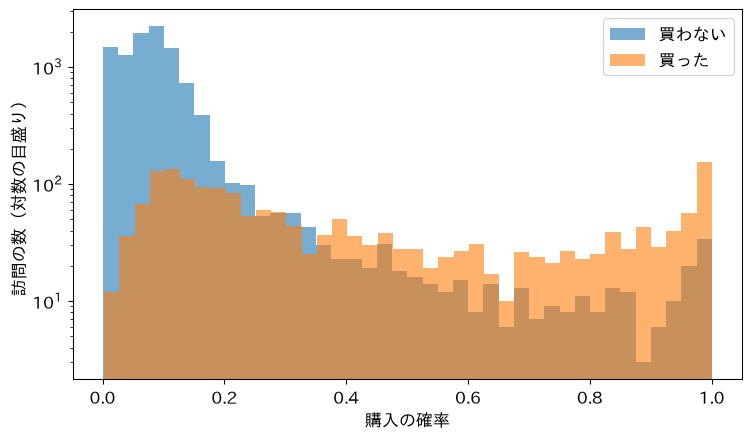

```python
plt.hist(df[df['購入'] == 0]['確率'], bins=40, alpha=0.6,
         label='買わない')
plt.hist(df[df['購入'] == 1]['確率'], bins=40, alpha=0.6,
         label='買った')
plt.yscale('log')
plt.xlabel('購入の確率')
plt.ylabel('訪問の数（対数の目盛り）')
plt.legend()
```

#### 1行ずつ読む

- 1〜4行目：買わなかった訪問と買った訪問の確率を、40本の柱で重ねて描く
- 5行目：縦の目盛りを対数にする（0の近くの柱が高すぎて、ほかが見えないため）
- 6〜8行目：軸の名前と、色の説明（凡例）を付ける

買わなかった訪問は、ほとんどが0の近くに集まります。買った訪問は、0から1まで広く散らばります。0の近くにも、買った訪問がかなりあり、ここが見逃しになります。

### お手本：0.5で切る

- 役割：確率が0.5以上なら購入と判定し、混同行列を数える（第6回）
- 入力：列「確率」と列「購入」
- 出力：列「判定」と、2×2の表

```python
from sklearn.metrics import confusion_matrix
df['判定'] = (df['確率'] >= 0.5).astype(int)
print(confusion_matrix(df['購入'], df['判定']))
```

```
[[10183   239]
 [ 1217   691]]
```

#### 1行ずつ読む

- 1行目：混同行列の道具を呼び出す
- 2行目：確率が0.5以上ならTrue。`astype(int)`で1と0に直し、列「判定」にしまう
- 3行目：本当（購入）と判定を渡し、2×2の表を表示する

#### 中身を見る：確率と判定

```python
df[['確率', '判定']].head(3)
```

|  | 確率 | 判定 |
| --- | --- | --- |
| 0 | 0.003592 | 0 |
| 1 | 0.035032 | 0 |
| 2 | 0.003592 | 0 |

確率が0.5より小さいので、3件とも判定は0（買わない）

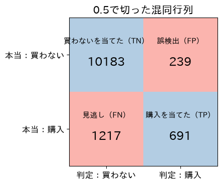

```
[[10183   239]
 [ 1217   691]]
```

買った1,908件のうち、1,217件を見逃しています。正解率は0.882で、何もしないとき（0.845）より少し高いだけです。

### お手本：AUCを出す

- 役割：しきい値を決めずに、確率の付き方そのものを測る（第6回）
- 入力：列「購入」と列「確率」
- 出力：AUC

```python
from sklearn.metrics import roc_auc_score
print(round(roc_auc_score(df['購入'], df['確率']), 3))
```

```
0.877
```

#### 1行ずつ読む

- 1行目：AUCの道具`roc_auc_score`を呼び出す
- 2行目：本当の答えと確率を渡すと、AUCが返る。しきい値は渡さない

AUCは0.877です。買った訪問1件と買わなかった訪問1件の組のうち、0.877の割合で、買った訪問の確率が高くなっています。

### TODO②：列を1本だけにする（予想 → 実行 → 比べる）

下のセルは、列の組`cols_x`で交差検証の確率を出し、AUCを表示します。

まず、予想を書いてください。商品ページにいた時間だけで確率を出すと、AUC（12本で0.877）はいくつになるでしょうか。

（ここに予想を書く）

予想を書いたら、セルの`cols`を`['商品ページ時間']`に替えて実行してください。

```python
# TODO: cols を ['商品ページ時間'] に替えて実行する
cols_x = cols
p = cross_val_predict(model, df[cols_x], df['購入'], cv=5,
                      method='predict_proba')
print(round(roc_auc_score(df['購入'], p[:, 1]), 3))
```

```
0.877
```

### やってみよう：予想と比べる

実行した結果を、予想と比べてください。1本だけのAUCは、12本と比べてどうでしたか。

（ここに答えを書く）

商品ページにいた時間だけでは、AUCは0.655です。12本の0.877より、ずっと低くなります。2節で差が見えた列でも、1本では見分けきれません。

### ここまでで分かったこと

| 段 | 分かったこと |
| --- | --- |
| 選ぶ・予想（1・2節） | UCIで3本を比べ、ネットショップの訪問を選んだ。購入は0.155 |
| 作って測る（3節） | 12本の列で確率。AUCは0.877。0.5では買った訪問の6割を見逃す |
| 確かめる（4節） | ？（このあとの段で） |
| しきい値を決める（5節） | ？（このあとの段で） |
| 時期で確かめる（6節） | ？（このあとの段で） |

まだ分からないのは、このAUCを信じてよいか、どの列が効いているか、です。

## 4. その成績、信じてよい？

ここから、段3「確かめる」（4節）です。問いは、AUC 0.877を信じてよいか、どの列が効いているか、です。

12本のうち、どの列が効いているのかを知るために、1本ずつ外して、AUCが下がるかを見ます。列を1本外して、確率を出し、AUCを測る。これを12本ぶん行います。同じ3行を12回書くのは、まちがいのもとです。そこで、手順に名前を付けて、関数にまとめます。

### 関数：第3回・第6回のおさらい

`def 名前(入力):`の下の字下げした行が、関数の中身で、呼ぶたびに動きます。`return`で答えを返します。入力を替えて呼ぶと、同じ手順が別の入力で動きます。

```python
def double(x):
    return 2 * x

print(double(3))
print(double(10))
```

```
6
20
```

### お手本：手順を関数にまとめる

- 役割：列の組を受け取り、交差検証で確率を出して、AUCを返す
- 入力：列の名前のリスト`cols`
- 出力：AUC（小数第3位まで）

```python
def auc_of(cols):
    p = cross_val_predict(model, df[cols], df['購入'], cv=5,
                          method='predict_proba')
    return round(roc_auc_score(df['購入'], p[:, 1]), 3)

print(auc_of(cols))
```

```
0.877
```

#### 1行ずつ読む

- 1行目：関数`auc_of`を作る。入力は、列の名前のリスト`cols`
- 2・3行目：3節と同じ。渡された列で、交差検証の確率を出す
- 4行目：AUCを出し、小数第3位までに丸めて返す
- 6行目：12本の列で呼ぶ。3節と同じ0.877が返る

#### 中身を見る：入力を替えて呼ぶ

```python
print(auc_of(['商品ページ時間']))
print(auc_of(['ページ価値']))
```

```
0.655
0.83
```

1行で、別の列の組を試せる。ページ価値1本だけで、0.830もある

### 関数は、手順に付けた名前

下の図は、関数`auc_of`に、3つの入力を渡したときの様子です。手順は1つで、入力（列の組）を替えて呼ぶたびに、同じ手順が動きます。

```
1 本の列 → auc_of → 0.655
1 本の列 → auc_of → 0.83
12 本の列 → auc_of → 0.877
```

> 今日の重要概念（Python）：関数

> 関数は、手順に名前を付けたもの。入力を替えて呼ぶたびに、同じ手順が動き、答えを返す。

### お手本：1本ずつ外す

- 役割：12本の列から1本ずつ外し、残りの11本でAUCを測る
- 入力：リスト`cols`と関数`auc_of`
- 出力：外した列の名前と、そのときのAUC（12行）

```python
for c in cols:
    rest = []
    for x in cols:
        if x != c:
            rest.append(x)
    print(c, auc_of(rest))
```

```
管理ページ数 0.877
管理ページ時間 0.877
情報ページ数 0.877
情報ページ時間 0.877
商品ページ数 0.876
商品ページ時間 0.876
直帰率 0.877
離脱率 0.882
ページ価値 0.718
特別な日 0.879
週末 0.877
新規 0.875
```

#### 1行ずつ読む

- 1行目：12本の列の名前を1つずつ`c`に入れ、字下げした行をくり返す。`c`が外す列
- 2行目：残す列をためる、空のリスト`rest`を作る
- 3行目：もう一度、12本の列を1つずつ`x`に入れてくり返す
- 4・5行目：`x`が外す列`c`でなければ（`!=`）、`rest`の後ろに足す
- 6行目：外した列の名前と、残りの11本で測ったAUCを表示する
- 関数があるので、くり返しの中身が1行で済む

#### 中身を見る：残した列

```python
c = 'ページ価値'
rest2 = []
for x in cols:
    if x != c:
        rest2.append(x)
print(len(rest2), 'ページ価値' in rest2)
```

```
11 False
```

外す列をページ価値に決めて、1回だけ回した。11本が残り、ページ価値は入っていない

えっ、ほかの列は、外してもAUCはほとんど変わりません（0.875〜0.882）。ページ価値を外したときだけ、0.877から0.718に下がります。

2節の予想と比べてみてください。たとえば「いちばん効くのは、商品ページにいた時間」と予想していたら、外れです。ページ価値1本で、ほとんど決まっていました。ページ価値とは、何なのでしょうか。

### お手本：ページ価値がある訪問

- 役割：ページ価値が0より大きい訪問の割合を、買わなかった訪問と買った訪問で比べる
- 入力：表`df`
- 出力：組ごとの割合

```python
df['価値あり'] = (df['ページ価値'] > 0).astype(int)
print(df.groupby('購入')['価値あり'].mean().round(3))
```

```
購入
0    0.114
1    0.806
Name: 価値あり, dtype: float64
```

#### 1行ずつ読む

- 1行目：ページ価値が0より大きければ1、0なら0の列「価値あり」を作る
- 2行目：購入の0と1で組に分け、「価値あり」の平均（1の割合）を出す

#### 中身を見る：ページ価値と価値あり

```python
df[['ページ価値', '価値あり', '購入']].head(3)
```

|  | ページ価値 | 価値あり | 購入 |
| --- | --- | --- | --- |
| 0 | 0.0 | 0 | 0 |
| 1 | 0.0 | 0 | 0 |
| 2 | 0.0 | 0 | 0 |

先頭の3件は、どれもページ価値が0なので、価値ありも0。購入も0

ページ価値が0より大きい訪問は、買わなかった訪問では0.114、買った訪問では0.806です。買った訪問の8割に、ページ価値があります。

### データの説明を読む

UCIのページには、こう書いてあります。

> The “Page Value” feature represents the average value for a web page that a user visited before completing an e-commerce transaction.

訳：ページ価値は、購入を終える前に見たページの、価値の平均。

ページの価値は、アクセス解析の道具（Google Analytics）が出す数です。購入の売上を、その購入の前に見られたページに割り振って、ページごとに計算します。購入が無ければ、ページの価値は付きません。答え（購入）から作られた列です。

では、使ってよいのでしょうか。過去の購入から前もって計算しておいた値なら、訪問の途中でも分かるので、使ってかまいません。この訪問の購入まで入れて計算した値なら、答えを見ていることになります。このデータの説明には、いつの購入から計算したかは書いてありません。

### お手本：ページ価値なしで切る

- 役割：ページ価値を除いた11本で確率を出し、0.5で切った混同行列を数える
- 入力：リスト`cols`
- 出力：2×2の表

```python
no_pv = []
for x in cols:
    if x != 'ページ価値':
        no_pv.append(x)
p = cross_val_predict(model, df[no_pv], df['購入'], cv=5,
                      method='predict_proba')
judge = (p[:, 1] >= 0.5).astype(int)
print(confusion_matrix(df['購入'], judge))
print(judge.sum(), round((judge == df['購入']).mean(), 3))
```

```
[[10400    22]
 [ 1900     8]]
30 0.844
```

#### 1行ずつ読む

- 1〜4行目：ページ価値を除いた11本の列を、リスト`no_pv`にためる
- 5・6行目：11本で、交差検証の確率を出す
- 7行目：0.5で切った判定を`judge`にしまう。8行目：混同行列を表示する
- 9行目：購入と判定した件数と、判定が当たった割合（正解率）を表示する

#### 中身を見る：11本の列

```python
print(len(no_pv))
print(no_pv[-4:])
```

```
11
['離脱率', '特別な日', '週末', '新規']
```

11本。後ろの4本に、ページ価値は無い（離脱率の次が特別な日）

ページ価値なしでは、購入と判定したのは30件だけです。正解率0.844は、何も言わないとき（0.845）より低くなります。

どちらで進むかを決めます。ここでは、店が過去の購入からページ価値を前もって計算している、と仮定します。この仮定のもとで、ページ価値を入れた12本で進みます。そして、仮定が崩れたら、AUCは0.718まで下がる、と書き添えます。期末レポートの「確かめた」は、この形で書きます。

> 重要：成績が良すぎる列は、データの説明を読み、何から作られた値かを確かめる。答えから作られた列なら、使ってよいかは、いつ計算したかで決まる。

### TODO③：外す列を替える（予想 → 実行 → 比べる）

下のセルは、列`c`を外した残りの列でAUCを測ります。

まず、予想を書いてください。離脱率を外すと、AUC（12本で0.877）はどうなるでしょうか。

（ここに予想を書く）

予想を書いたら、セルの`'ページ価値'`を`'離脱率'`に替えて実行してください。

```python
# TODO: 'ページ価値' を '離脱率' に替えて実行する
c = 'ページ価値'
rest_x = []
for x in cols:
    if x != c:
        rest_x.append(x)
print(auc_of(rest_x))
```

```
0.718
```

### やってみよう：予想と比べる

実行した結果を、予想と比べてください。離脱率を外したAUCは、ページ価値を外したときと比べてどうでしたか。

（ここに答えを書く）

離脱率を外すと0.882です。下がるどころか、わずかに上がりました。外しても困らない列もあります。効いているのは、ページ価値でした。

### ここまでで分かったこと

| 段 | 分かったこと |
| --- | --- |
| 選ぶ・予想（1・2節） | UCIで3本を比べ、ネットショップの訪問を選んだ。購入は0.155 |
| 作って測る（3節） | 12本の列で確率。AUCは0.877。0.5では買った訪問の6割を見逃す |
| 確かめる（4節） | ページ価値を外すとAUC 0.718。購入から計算された列。仮定を置いて使う |
| しきい値を決める（5節） | ？（このあとの段で） |
| 時期で確かめる（6節） | ？（このあとの段で） |

まだ分からないのは、確率をどこで切ればよいか、です。

## 5. どこで切る？

ここから、段4「しきい値を決める」（5節）です。問いは、確率をどこで切って、声をかける訪問を決めるか、です。

12本の列で確率を出し、AUCは0.877でした。ページ価値は、仮定を置いて使います。0.5で切ると、買った1,908件のうち1,217件を見逃しました。0.5でよいのでしょうか。2つの誤りの重さから決めます。

### 2つの誤りに、重さを置く

確率がしきい値以上の訪問に、チャットの担当者が声をかけます。見逃しは、買う気のある訪問に声をかけそびれることで、売上の機会を逃します。誤検出は、買わない訪問に担当者の時間を使うことです。

誤検出1件の損を1とし、見逃し1件の損を$c_{FN}$とします。

$$\text{損の合計} = c_{FN} \times \text{見逃しの件数} + 1 \times \text{誤検出の件数}$$

ここでは、見逃しは誤検出の5倍重い（$c_{FN} = 5$）と置きます。これは仮定です。0.5で切ると、見逃し1,217件、誤検出239件なので、損の合計は5 × 1,217 + 239 = 6,324です。

しきい値を下げると、見逃しが減り、誤検出が増えます（第6回）。損はどうなるでしょうか。

### お手本：しきい値ごとの損

- 役割：しきい値を0.01から0.99まで動かし、そのたびに損の合計を数えて、リストにためる
- 入力：列「確率」と列「購入」、見逃しの重さ`c_fn`
- 出力：リスト`ts`（しきい値）と`costs`（損の合計）

```python
c_fn = 5
ts = []
costs = []
for k in range(1, 100):
    t = k / 100
    m = confusion_matrix(df['購入'], (df['確率'] >= t).astype(int))
    ts.append(t)
    costs.append(c_fn * m[1, 0] + m[0, 1])
print(ts[0], ts[-1], costs[49])
```

```
0.01 0.99 6324
```

#### 1行ずつ読む

- 1行目：見逃し1件の重さ`c_fn`を5にする
- 2・3行目：しきい値をためるリスト`ts`と、損をためるリスト`costs`を、空で作る
- 4行目：`k`を1から99まで1つずつ変えて、くり返す
- 5行目：`k / 100`で、しきい値`t`は0.01から0.99まで
- 6行目：しきい値`t`で切った判定の混同行列を、`m`にしまう
- 7行目：しきい値を`ts`に足す
- 8行目：`m[1, 0]`は見逃し、`m[0, 1]`は誤検出（第6回）。損の合計を`costs`に足す
- 9行目：最初と最後のしきい値と、50番目（しきい値0.5）の損を表示する

#### 中身を見る：最初の3回

```python
for k in range(1, 4):
    t = k / 100
    m = confusion_matrix(df['購入'], (df['確率'] >= t).astype(int))
    print(t, m[1, 0], m[0, 1], c_fn * m[1, 0] + m[0, 1])
```

```
0.01 3 9532 9547
0.02 7 9205 9240
0.03 14 8799 8869
```

しきい値がとても低いと、見逃しは少ないが、誤検出が数千件。損は大きい

### お手本：損を描く

- 役割：しきい値と損の合計を線で描く
- 入力：リスト`ts`と`costs`
- 出力：線の図

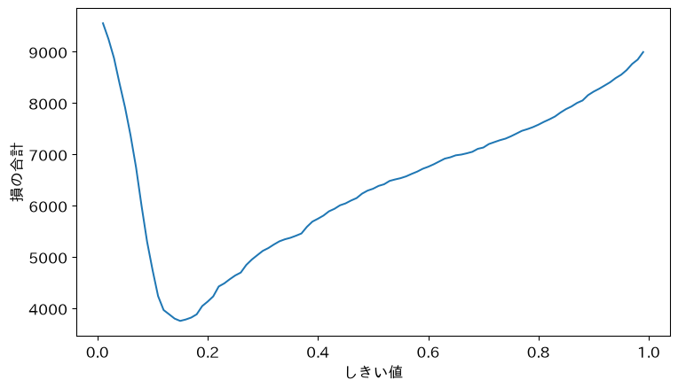

```python
plt.plot(ts, costs)
plt.xlabel('しきい値')
plt.ylabel('損の合計')
```

#### 1行ずつ読む

- 1行目：横にしきい値、縦に損の合計を取り、99個の点を線でつなぐ
- 2・3行目：軸の名前を付ける

損には谷があります。しきい値が低すぎると、誤検出で損が増えます。高すぎると、見逃しで損が増えます。0.5は、谷の底から遠いところです。谷の底のしきい値で切れば、損がいちばん小さくなります。

### お手本：いちばん小さいところ

- 役割：損の合計がいちばん小さいしきい値を探す
- 入力：リスト`ts`と`costs`
- 出力：しきい値と、そのときの損

```python
i = costs.index(min(costs))
print(ts[i], costs[i])
```

```
0.15 3749
```

#### 1行ずつ読む

- 1行目：`min(costs)`で、いちばん小さい損を出す
- 続けて`costs.index(…)`で、それがリストの何番目かを調べ、`i`にしまう
- 2行目：`i`番目のしきい値と、そのときの損を表示する

#### 中身を見る：indexの動き

```python
a = [30, 10, 20]
print(min(a), a.index(min(a)))
```

```
10 1
```

いちばん小さいのは10で、リストの1番目（0から数える）

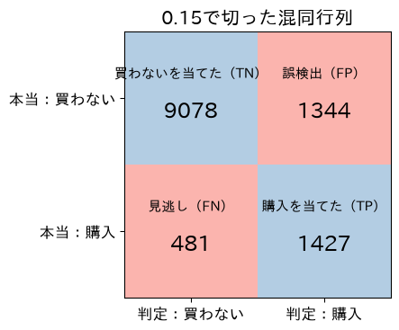

```
[[9078 1344]
 [ 481 1427]]
```

見逃しを5倍と置くと、0.15で切るのが、損がいちばん小さくなります。見逃しは1,217件から481件に減り、誤検出は239件から1,344件に増えました。損の合計は、6,324から3,749に下がります。

> 今日の重要概念（統計）：しきい値は誤りの重さで決める

> しきい値は0.5に決まっていない。見逃しと誤検出に重さを置き、損の合計がいちばん小さいところで切る。

```
重さ 1  しきい値 0.36  見逃し 1008  誤検出 368
重さ 2  しきい値 0.18  見逃し 595  誤検出 902
重さ 5  しきい値 0.15  見逃し 481  誤検出 1344
重さ 10  しきい値 0.12  見逃し 335  誤検出 2286
```

### 重さを替えると

| 見逃しの重さ $c_{FN}$ | しきい値 | 見逃し | 誤検出 |
| --- | --- | --- | --- |
| 1 | 0.36 | 1,008 | 368 |
| 2 | 0.18 | 595 | 902 |
| 5 | 0.15 | 481 | 1,344 |
| 10 | 0.12 | 335 | 2,286 |

見逃しを重くするほど、しきい値は下がり、たくさんの訪問に声をかけます。

重さは、データからは出てきません。見逃し1件と誤検出1件の重さは、店が決めます。1件の売上、担当者の数と時間、お客の印象などで決まります。期末レポートでは、重さを仮定として書き、替えたらどうなるかも見せます。

### TODO④：見逃しの重さを替える（予想 → 実行 → 比べる）

下のセルは、見逃しの重さ`c_fn`で、しきい値ごとの損を数え、いちばん小さいしきい値と損を表示します。

まず、予想を書いてください。見逃しと誤検出を同じ重さ（1）にすると、しきい値（5倍で0.15）はどうなるでしょうか。0.5になるでしょうか。

（ここに予想を書く）

予想を書いたら、セルの`5`を`1`に替えて実行してください。

```python
# TODO: 5 を 1 に替えて実行する
c_fn = 5
costs_x = []
for t in ts:
    m = confusion_matrix(df['購入'], (df['確率'] >= t).astype(int))
    costs_x.append(c_fn * m[1, 0] + m[0, 1])
i = costs_x.index(min(costs_x))
print(ts[i], costs_x[i])
```

```
0.15 3749
```

### やってみよう：予想と比べる

実行した結果を、予想と比べてください。同じ重さのときのしきい値は、0.5でしたか。

（ここに答えを書く）

同じ重さなら、しきい値は0.36です。0.5ではありません。ロジスティック回帰の確率は、ぴったり正しい確率とは限りません。だから、式で決めずに、損を数えて決めます。

### ここまでで分かったこと

| 段 | 分かったこと |
| --- | --- |
| 選ぶ・予想（1・2節） | UCIで3本を比べ、ネットショップの訪問を選んだ。購入は0.155 |
| 作って測る（3節） | 12本の列で確率。AUCは0.877。0.5では買った訪問の6割を見逃す |
| 確かめる（4節） | ページ価値を外すとAUC 0.718。購入から計算された列。仮定を置いて使う |
| しきい値を決める（5節） | 見逃しを5倍と置くと、0.15で切る。損は6,324から3,749に |
| 時期で確かめる（6節） | ？（このあとの段で） |

まだ分からないのは、決めたしきい値が、これからの訪問にも使えるか、です。

## 6. 年末にも使える？

ここから、段5「時期で確かめる」（6節）です。問いは、手元のデータで決めたしきい値を、これからの訪問にも使ってよいか、です。

見逃しを5倍と置くと、0.15で切るのが、損がいちばん小さくなりました。ただし、そのしきい値は、手元の全部の訪問で決めました。実際には、決めたしきい値を、これからの訪問に使います。これからも、今までと同じでしょうか。

そこで、2〜10月の訪問で式を作ってしきい値を決め（過去）、11・12月の訪問に当てて、確率と損を測ります（これから）。交差検証は時期を混ぜて分けるので、「これから」を確かめるには、時期で分けます。

### お手本：時期で分ける

- 役割：年末（11・12月）と、それより前（2〜10月）に分け、訪問の数と購入の割合を見る
- 入力：表`df`の月の列`Month`
- 出力：`late`・`early`（TrueとFalseの列）

```python
late = df['Month'].isin(['Nov', 'Dec'])
early = ~late
print(early.sum(), late.sum())
print(round(df.loc[early, '購入'].mean(), 3),
      round(df.loc[late, '購入'].mean(), 3))
```

```
7605 4725
0.123 0.207
```

#### 1行ずつ読む

- 1行目：月が11月か12月ならTrue（`isin`）。年末の訪問
- 2行目：`~`でTrueとFalseを入れ替える。2〜10月の訪問
- 3〜5行目：訪問の数と、購入の割合

年末は購入が多くなっています（0.123と0.207）。

### お手本：過去で作り、年末に当てる

- 役割：過去の中だけで交差検証の確率を出し、過去の全部で式を作って、年末の確率を出す
- 入力：`model`、`cols`、`early`・`late`
- 出力：確率`p_e`（過去）と`p_l`（年末）、2つのAUC

```python
y_e = df.loc[early, '購入']
y_l = df.loc[late, '購入']
p_e = cross_val_predict(model, df.loc[early, cols], y_e, cv=5,
                        method='predict_proba')[:, 1]
model.fit(df.loc[early, cols], y_e)
p_l = model.predict_proba(df.loc[late, cols])[:, 1]
auc_e = roc_auc_score(y_e, p_e)
auc_l = roc_auc_score(y_l, p_l)
print(round(auc_e, 3), round(auc_l, 3))
```

```
0.906 0.826
```

#### 1行ずつ読む

- 1・2行目：過去と年末の、購入の列
- 3・4行目：過去の中だけで、交差検証の確率を出す（3節と同じ）
- 5・6行目：過去の全部で式を作り（`fit`）、年末の訪問の確率を出す（`predict_proba`）
- 7〜9行目：過去（交差検証）と年末のAUC

年末のAUCは、0.906から0.826に下がりました。

```python
print(p_l.mean().round(3), y_l.mean().round(3))
```

```
0.148 0.207
```

えっ、年末の確率の平均は0.148なのに、実際に買ったのは0.207です。過去の式は、年末の「買いやすさ」を知りません。見分ける力（AUC）も下がりました。

### お手本：2つの関数

過去と年末で、同じ「損を数えて、いちばん小さい所を探す」をくり返します。5節の手順を、関数にまとめます（4節の関数と同じ考え）。

- 役割：`cost_at`はしきい値`t`で切ったときの損を、`best_threshold`は損がいちばん小さいしきい値を返す
- 入力：答え`y`、確率`p`、しきい値`t`、重さ`c_fn`
- 出力：損、またはしきい値

```python
def cost_at(y, p, t, c_fn):
    m = confusion_matrix(y, (p >= t).astype(int))
    return c_fn * m[1, 0] + m[0, 1]


def best_threshold(y, p, c_fn):
    costs = []
    for k in range(1, 100):
        costs.append(cost_at(y, p, k / 100, c_fn))
    i = costs.index(min(costs))
    return (i + 1) / 100
```

#### 1行ずつ読む

- 1〜3行目：しきい値`t`で切った混同行列から、損の合計を返す（5節と同じ計算）
- 6・7行目：入力は答え`y`・確率`p`・重さ`c_fn`。損をためるリストを作る
- 8・9行目：しきい値0.01〜0.99で、1つ目の関数`cost_at`を呼んで損をためる
- 10・11行目：いちばん小さい損の位置から、しきい値を返す（`i`番目は`(i + 1) / 100`）

### お手本：過去で決め、年末で測る

```python
t_e = best_threshold(y_e, p_e, 5)
t_l = best_threshold(y_l, p_l, 5)
print(t_e, t_l)
print(cost_at(y_l, p_l, t_e, 5), cost_at(y_l, p_l, t_l, 5))
```

```
0.12 0.09
2289 2123
```

#### 1行ずつ読む

- 1行目：過去で決めたしきい値
- 2行目：年末の答えを知っていたら選べた、年末の最良
- 3・4行目：2つのしきい値と、年末の損

過去で決めた0.12は、年末の最良0.09からずれ、損が166だけ大きくなります。

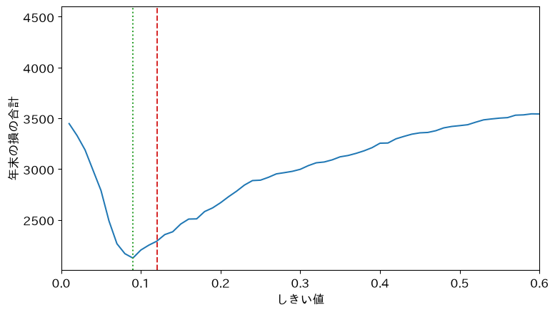

```python
ts_l = []
costs_l = []
for k in range(1, 100):
    ts_l.append(k / 100)
    costs_l.append(cost_at(y_l, p_l, k / 100, 5))
plt.plot(ts_l, costs_l)
plt.axvline(t_e, color='tab:red', linestyle='--')
plt.axvline(t_l, color='tab:green', linestyle=':')
plt.xlim(0, 0.6)
plt.xlabel('しきい値')
plt.ylabel('年末の損の合計')
plt.show()
```

年末の谷の底は0.09（緑）です。過去で決めた0.12（赤）は、底から少し右にずれています。

> 重要：購入の割合や見分ける力は、時期で変わる。手元で決めたしきい値は、新しい時期のデータで確かめ直す。

### TODO⑤：重さを10にする（予想 → 実行 → 比べる）

下のセルは、見逃しの重さ`c_fn`で、過去で決めたしきい値と年末の最良、それぞれの年末の損を表示します。

まず、予想を書いてください。見逃しをもっと重くすると、過去で決めたしきい値のずれは大きくなるでしょうか。

（ここに予想を書く）

予想を書いたら、セルの`5`を`10`に替えて実行してください（`c_fn = 5`の行）。

```python
# TODO: 5 を 10 に替えて実行する
c_fn = 5
t_e = best_threshold(y_e, p_e, c_fn)
t_l = best_threshold(y_l, p_l, c_fn)
print(t_e, t_l)
print(cost_at(y_l, p_l, t_e, c_fn), cost_at(y_l, p_l, t_l, c_fn))
```

```
0.12 0.09
2289 2123
```

### やってみよう：予想と比べる

実行した結果を、予想と比べてください。ずれと損の差は、どう変わりましたか。

（ここに答えを書く）

重さ10では、過去で決めた0.1と年末の最良0.06の差が広がり、損の差は863（3962と3099）になります。見逃しを重くするほど、年末の「買いやすさ」を見落とした分が、大きく効きます。

### ここまでで分かったこと

| 段 | 分かったこと |
| --- | --- |
| 選ぶ・予想（1・2節） | UCIで3本を比べ、ネットショップの訪問を選んだ。購入は0.155 |
| 作って測る（3節） | 12本の列で確率。AUCは0.877。0.5では買った訪問の6割を見逃す |
| 確かめる（4節） | ページ価値を外すとAUC 0.718。購入から計算された列。仮定を置いて使う |
| しきい値を決める（5節） | 見逃しを5倍と置くと、0.15で切る。損は6,324から3,749に |
| 時期で確かめる（6節） | 2〜10月で決めた0.12は、年末には最良でない（年末の最良は0.09） |

5つの段がそろい、今日の問いに答えられます。

### 答え

12本の列でロジスティック回帰の確率を出すと、AUCは0.877です。効いているのはページ価値で、購入から計算された列なので、仮定を置いて使います。見逃しを誤検出の5倍と置くと、0.15で切るのが、損の合計がいちばん小さくなります。そのとき、買った1,908件のうち1,427件に声をかけ、買わない1,344件にも声をかけます。

まだ言えないこと

- ページ価値の仮定：いつの購入から計算したかは、店に聞かないと分からない
- 重さ：5倍という数は仮定。実際の売上と担当者の時間から決めたい
- 声をかけたら買うか：このデータは、声をかけなかったときの記録

### レポートなら、こう書く

今日の解析を、期末レポートの項目に写すと、次のようになります。

- 選んだ理由：実際のネットショップの記録で、1行が身近。作ったデータの2本は外した
- 予想：いちばん効くのは、商品ページにいた時間だろう
- 解析：12本の列でロジスティック回帰の確率を出し、AUCは0.877
- 確かめた：1本ずつ外すと、ページ価値だけで0.718に下がる。説明を読み、仮定を置いた
- 驚き：予想した商品ページの時間ではなく、ページ価値1本でほぼ決まっていた
- 決めた：見逃しを5倍と置き、0.15で切る。重さを替えた表も付ける

## 目標に答えられたか

- 今日の目標は「ネットショップの訪問から、購入を見分けられるか。見分けたとして、どこで切ればよいか」でした。AUCと、しきい値と、損の合計で答えられますか？
- 1節で、工作機械ときのこのデータを外したのはなぜですか？
- 3節で、`make_pipeline`でつないだ標準化は、どの組のデータで平均と標準偏差を覚えましたか？
- 4節で、関数`auc_of`を作ると、何が楽になりましたか？
- 4節で、ページ価値を使ってよいかが、データの説明だけでは決まらないのはなぜですか？
- 5節で、見逃しを重くすると、しきい値はどちらへ動きましたか？

## 今日の要点

- 今日、持ち帰る1文：しきい値は0.5に決まっていない。見逃しと誤検出の重さを置けば、しきい値が決まる。そして、成績を決めている列が何から作られたかを、データの説明で確かめる
- 重要概念（統計）：しきい値は誤りの重さで決める。見逃しと誤検出に重さを置き、損の合計がいちばん小さいところで切る
- 重要概念（Python）：関数。手順に名前を付けたもの。入力を替えて呼ぶたびに、同じ手順が動き、答えを返す
- データは、ページの説明まで読んで選ぶ。作ったデータか、人を判定しないか
- 成績が良すぎる列は、何から作られたかを確かめる。重さは仮定として書く

## 次回へ

今日は、答えの列（購入）があるデータで、確率を出して切りました。では、答えの列が無いとき、似た行をまとめて、群に分けられるでしょうか。

## 課題（提出）

提出するもの：絵2枚（画像ファイル）。今日の重要概念の、統計とPythonを1枚ずつです。提出フォームから出してください。期限はありません。

コードは書きません。上手な絵である必要はありません。紙に手で描いて写真を撮っても、描画アプリで描いてもかまいません。

### 今日の重要概念（2つ）

- 統計：しきい値は誤りの重さで決める。しきい値は0.5に決まっていない。見逃しと誤検出に重さを置き、損の合計がいちばん小さいところで切る（5節）
- Python：関数。手順に名前を付けたもの。入力を替えて呼ぶたびに、同じ手順が動き、答えを返す（4節）

### 今日の2枚（絵にする）

2つの重要概念を、1枚ずつ絵にしてください。その考えが1枚で伝わる絵です。数式やコードは描かなくてかまいません。半年後の自分が見て、何の話だったか思い出せる絵を目指します。

**詰まったら**

しきい値と誤りの重さなら、たとえば「天気予報を見て、傘を持っていくか」を描けます。 濡れるのがとても嫌な人は、降水確率20%でも持っていきます。荷物が重いのが嫌な人は、70%まで持ちません。同じ予報でも、誤りの重さで決め方が変わります。5節の損の谷の図が手本になります。

**詰まったら**

関数なら、たとえば「炊飯器の『炊く』ボタン」を描けます。 手順（水を吸わせる、加熱する、蒸らす）は1つです。お米を替えて押すたびに、同じ手順が動き、ごはんが返ります。4節の`auc_of`に3つの入力を渡す図が手本になります。

## 発展（任意）

### 月も、手がかりにしたら？

購入の割合は、月で違います（11月は0.254、2月は0.016）。月を0と1の列にして足すと、AUCは上がるでしょうか。`pd.get_dummies`は、月ごとに「その月なら1」の列を作る道具です。

```python
print(df.groupby('Month')['購入'].mean().round(3))
```

```
Month
Aug     0.176
Dec     0.125
Feb     0.016
Jul     0.153
June    0.101
Mar     0.101
May     0.109
Nov     0.254
Oct     0.209
Sep     0.192
Name: 購入, dtype: float64
```

```python
mon = pd.get_dummies(df['Month'], dtype=int)
X_mon = pd.concat([df[cols], mon], axis=1)
p = cross_val_predict(model, X_mon, df['購入'], cv=5,
                      method='predict_proba')
print(round(roc_auc_score(df['購入'], p[:, 1]), 3))
```

```
0.859
```

#### 1行ずつ読む

- 1行目：月ごとの0と1の列（10か月ぶん）を作る
- 2行目：12本の列と月の列を、横につなぐ
- 3〜5行目：交差検証の確率を出し、AUCを表示する

月を足したら、0.877から0.859に下がりました。下の表で、組ごとの月の件数を見ます。

```python
fold = np.arange(len(df)) * 5 // len(df) + 1
pd.crosstab(fold, df['Month'])[['Feb', 'Mar', 'May', 'Nov', 'Dec']]
```

| Month row_0 | Feb | Mar | May | Nov | Dec |
| --- | --- | --- | --- | --- | --- |
| 1 | 184 | 1907 | 375 | 0 | 0 |
| 2 | 0 | 0 | 2466 | 0 | 0 |
| 3 | 0 | 0 | 523 | 284 | 0 |
| 4 | 0 | 0 | 0 | 1224 | 751 |
| 5 | 0 | 0 | 0 | 1490 | 976 |

#### 1行ずつ読む

- 1行目：上から順に5つの組に分けたときの、組の番号（1〜5）を作る
- 2行目：組と月の組み合わせごとに件数を数え（`pd.crosstab`）、5つの月を表示する

表はほぼ月の順に並んでいて、上から5つに分けると、2月と3月は1つ目の組にしかありません。1つ目の組の確率を出すとき、式は2月と3月を一度も見ていないのです。

行を混ぜてから5つの組に分けると、どうなるでしょうか。`KFold(5, shuffle=True, random_state=0)`は、行を混ぜてから5つに分ける分け方です。

```python
from sklearn.model_selection import KFold
shuf = KFold(5, shuffle=True, random_state=0)
p = cross_val_predict(model, X_mon, df['購入'], cv=shuf,
                      method='predict_proba')
print(round(roc_auc_score(df['購入'], p[:, 1]), 3))
```

```
0.894
```

行を混ぜると、月を足して0.894に上がります。どちらが正しいかは、何を当てたいかで決まります。来月の訪問を当てたいなら、上から順に分けたほうが、実際の使い方に近い分け方です。

試すなら、月の代わりに、流入元（`TrafficType`）を`pd.get_dummies`で足してみましょう。番号の列も、0と1の列にすれば使えます。